# Season report: LoneWolf Season 15

#### Popular variations

All openings played in the season, including variations.

| Rank | Opening | Games | White % | 1-0 % | Draw % | 0-1 % | Mean Eval | Avg Rating |
| --- | --- | --- | --- | --- | --- | --- | --- | --- |
| 1 | Indian Defense | 19 | 55.2631578947368 | 52.6315789473684 | 5.26315789473684 | 42.1052631578947 | 1.16388888888889 | 1933.60526315789 |
| 2 | Queen's Pawn Game: Mason Variation | 10 | 65 | 60 | 10 | 30 | 1.96 | 1849.5 |
| 3 | Caro-Kann Defense: Advance Variation, Short Variation | 5 | 30 | 20 | 20 | 60 | 0.092 | 1883.7 |
| 3 | Queen's Gambit Declined: Exchange Variation, Positional Variation | 5 | 50 | 40 | 20 | 40 | 0.364 | 1966.6 |
| 3 | Sicilian Defense: Closed, Traditional | 5 | 50 | 40 | 20 | 40 | 0.425 | 1881.7 |
| 3 | Sicilian Defense: Nyezhmetdinov-Rossolimo Attack, Fianchetto Variation | 5 | 60 | 60 | 0 | 40 | -0.666 | 2018.1 |
| 4 | Caro-Kann Defense: Exchange Variation | 4 | 37.5 | 25 | 25 | 50 | -0.1875 | 1945 |
| 4 | Catalan Opening: Closed | 4 | 25 | 0 | 50 | 50 | -0.89 | 1934.25 |
| 4 | Dutch Defense | 4 | 50 | 50 | 0 | 50 | 0.9425 | 1905.125 |
| 4 | French Defense: Exchange Variation | 4 | 37.5 | 25 | 25 | 50 | -2.02 | 1984 |

[output cut: 217 more lines]

#### Best for White

The best-scoring main openings for White.

*Includes all main openings played in at least 10 games.*

| Rank | Opening | Games | White's score (%) | White wins (%) | Draws (%) | Black wins (%) | Mean eval after 15 moves | Avg rating |
| --- | --- | --- | --- | --- | --- | --- | --- | --- |
| 1 | Nimzo-Indian Defense | 12 | 62.5 | 50 | 25 | 25 | 0.826666666666667 | 1939 |
| 2 | Sicilian Defense | 68 | 61.0294117647059 | 52.9411764705882 | 16.1764705882353 | 30.8823529411765 | 0.605538461538461 | 1937.77205882353 |
| 3 | English Opening | 22 | 59.0909090909091 | 54.5454545454545 | 9.09090909090909 | 36.3636363636364 | 1.4805 | 1895.84090909091 |
| 4 | Scandinavian Defense | 13 | 57.6923076923077 | 53.8461538461538 | 7.69230769230769 | 38.4615384615385 | 0.653846153846154 | 1973.23076923077 |
| 5 | Ruy Lopez | 16 | 56.25 | 50 | 12.5 | 37.5 | 0.72125 | 2063.625 |
| 6 | Queen's Gambit Declined | 21 | 52.3809523809524 | 38.0952380952381 | 28.5714285714286 | 33.3333333333333 | 0.382380952380952 | 1973.30952380952 |
| 7 | French Defense | 20 | 47.5 | 40 | 15 | 45 | -0.297368421052632 | 1960.425 |
| 8 | Queen's Pawn Game | 18 | 47.2222222222222 | 44.4444444444444 | 5.55555555555556 | 50 | 0.853888888888889 | 1870.61111111111 |
| 9 | Indian Defense | 25 | 46 | 44 | 4 | 52 | 0.949166666666667 | 1954.96 |
| 10 | Slav Defense | 12 | 41.6666666666667 | 25 | 33.3333333333333 | 41.6666666666667 | -0.0633333333333333 | 2010.20833333333 |

[output cut: 1 more lines]

#### Best for Black

The best-scoring main openings for Black.

*Includes all main openings played in at least 10 games.*

| Rank | Opening | Games | Black's score (%) | Black wins (%) | Draws (%) | White wins (%) | Mean eval after 15 moves | Avg rating |
| --- | --- | --- | --- | --- | --- | --- | --- | --- |
| 1 | Caro-Kann Defense | 27 | 61.1111111111111 | 51.8518518518518 | 18.5185185185185 | 29.6296296296296 | 0.556296296296296 | 1888 |
| 2 | Slav Defense | 12 | 58.3333333333333 | 41.6666666666667 | 33.3333333333333 | 25 | -0.0633333333333333 | 2010.20833333333 |
| 3 | Indian Defense | 25 | 54 | 52 | 4 | 44 | 0.949166666666667 | 1954.96 |
| 4 | Queen's Pawn Game | 18 | 52.7777777777778 | 50 | 5.55555555555556 | 44.4444444444444 | 0.853888888888889 | 1870.61111111111 |
| 5 | French Defense | 20 | 52.5 | 45 | 15 | 40 | -0.297368421052632 | 1960.425 |
| 6 | Queen's Gambit Declined | 21 | 47.6190476190476 | 33.3333333333333 | 28.5714285714286 | 38.0952380952381 | 0.382380952380952 | 1973.30952380952 |
| 7 | Ruy Lopez | 16 | 43.75 | 37.5 | 12.5 | 50 | 0.72125 | 2063.625 |
| 8 | Scandinavian Defense | 13 | 42.3076923076923 | 38.4615384615385 | 7.69230769230769 | 53.8461538461538 | 0.653846153846154 | 1973.23076923077 |
| 9 | English Opening | 22 | 40.9090909090909 | 36.3636363636364 | 9.09090909090909 | 54.5454545454545 | 1.4805 | 1895.84090909091 |
| 10 | Sicilian Defense | 68 | 38.9705882352941 | 30.8823529411765 | 16.1764705882353 | 52.9411764705882 | 0.605538461538461 | 1937.77205882353 |

[output cut: 1 more lines]

#### Popular gambits

All gambit openings played in the season.[^4]

| Rank | Name | Games | White score (%) |
| --- | --- | --- | --- |
| 1 | Benko Gambit | 3 | 66.6666666666667 |
| 2 | Scotch Gambit | 1 | 100 |
| 2 | Stafford Gambit | 1 | 100 |
| 3 | Blumenfeld Countergambit | 1 | 50 |
| 4 | Andreaschek Gambit | 1 | 0 |
| 4 | Geller Gambit | 1 | 0 |
| 4 | Staunton Gambit | 1 | 0 |
| 4 | Vienna Gambit | 1 | 0 |

#### Gambiteers

The players who enjoyed the most success when playing gambits.[^5]

*Shows all players who scored at least 50% playing gambits in the season (min. games: 2).*

| Rank | Player | Games | % Score |
| --- | --- | --- | --- |

### Openings - sunburst

Click on the image below to see a sunburst plot of all openings played in the season.

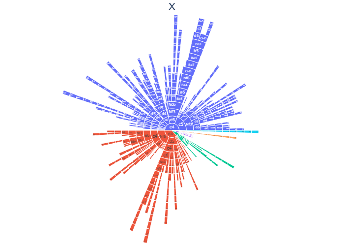

### Awards

Because winning isn’t everything; it’s the only thing :)

See the footnote for further details on selected awards.[^6]

| Award | Description | Winner | Details | Honourable mentions |
| --- | --- | --- | --- | --- |
| x | Archbishop of Accuracy | ErinYu | 20.8 ACPL over 497 moves | SycoraxCirce, checkmonk |
| x | Bullet Boss | Thundercougarfalcon | 25 moves | Spaceball, jessehf |
| x | David Award | Chaskar | Opponents' record: 41.5/54 | Flaneur, ErinYu |
| x | Gambit Guru |  | Can't be awarded |  |
| x | Giri Award | checkmonk, Fianchettoed, IsaVulpes, jessehf, mathijshuis, matrix47, mronemore, neil1996, OuterHeaven92, SycoraxCirce | 3 draws |  |
| x | Grischuk's Cousin | jfarah | Had 10m 56s left after 10 moves | astralfenix, k-night-moves |
| x | Houdini Award | ErinYu |  | ChristopherChabris, supermaths |
| x | Intimate with Increment | pepepibote | 49.8% | Sesquipedalism, jfarah |
| x | Musing or Snoozing | paintman | Spent 22m 8s | Ahedrista, k-night-moves |
| x | MVP Award | Chaskar | +6-3=0 perf 2278, initially 1996 | JSlavik, TenThousandHours |

[output cut: 7 more lines]

### Detailed statistics

All the following tables are sortable and searchable.

#### Best performances / highest accuracy

##### Best relative perfs

Shows players’ *relative* performance ratings: season performance rating minus initial rating.[^7]

*Includes all players with a positive relative performance rating over at least five games.*

| # | Player | Games | W | D | L | Initial | Perf | Diff. |
| --- | --- | --- | --- | --- | --- | --- | --- | --- |
| 1 | Chaskar | 9 | 6 | 0 | 3 | 1996 | 2278.33333333333 | 282.333333333333 |
| 2 | JSlavik | 9 | 4 | 1 | 4 | 1813 | 2073 | 260 |
| 3 | TenThousandHours | 6 | 5 | 1 | 0 | 2199 | 2448.33333333333 | 249.333333333333 |
| 4 | Fianchettoed | 7 | 3 | 3 | 1 | 1873 | 2082.57142857143 | 209.571428571428 |
| 5 | ErinYu | 11 | 9 | 2 | 0 | 2303 | 2495.81818181818 | 192.818181818182 |
| 6 | Tactix47 | 9 | 5 | 0 | 4 | 1913 | 2093 | 180 |
| 7 | chesseric44 | 6 | 2 | 2 | 2 | 1834 | 1988.16666666667 | 154.166666666667 |
| 8 | paintman | 8 | 4 | 0 | 4 | 1858 | 2007.875 | 149.875 |
| 9 | rliu347 | 6 | 2 | 1 | 3 | 1749 | 1897.66666666667 | 148.666666666667 |
| 10 | atil4 | 9 | 5 | 0 | 4 | 1851 | 1998.44444444444 | 147.444444444444 |

[output cut: 34 more lines]

##### Lowest ACPL

*Includes the 100 players with the lowest ACPL (min. 100 moves played).*

| Rank | Player | Moves | ACPL |
| --- | --- | --- | --- |
| 1 | ErinYu | 497 | 20.7605633802817 |
| 2 | SycoraxCirce | 137 | 21.1459854014599 |
| 3 | checkmonk | 171 | 23.1520467836257 |
| 4 | Tianmu | 196 | 24.6326530612245 |
| 5 | IsaVulpes | 159 | 24.8490566037736 |
| 6 | Fianchettoed | 279 | 25.1720430107527 |
| 7 | makeareason | 106 | 26.4150943396226 |
| 8 | neil1996 | 225 | 27.8622222222222 |
| 9 | jessehf | 399 | 28.4411027568922 |
| 10 | alms | 205 | 28.4975609756098 |

[output cut: 88 more lines]

#### Time spent / strongest opponents

##### Time spent

*Includes the 50 players who spent the most clock time over the season.*

| Rank | Player | Games | Total time spent |
| --- | --- | --- | --- |
| 1 | ErinYu | 11 | 8h 28m 22s |
| 2 | supermaths | 11 | 8h 0m 27s |
| 3 | Thundercougarfalcon | 11 | 7h 59m 41s |
| 4 | Spaceball | 10 | 7h 36m 15s |
| 5 | f1nn33 | 11 | 7h 12m 17s |
| 6 | ChristopherChabris | 10 | 7h 10m 52s |
| 7 | GGrkinic | 10 | 7h 0m 43s |
| 8 | WildGooseChess | 9 | 7h 0m 24s |
| 9 | k-night-moves | 9 | 6h 46m 11s |
| 10 | OneKindKing | 11 | 6h 43m 15s |

[output cut: 40 more lines]

##### Time spent per move (after move 10)

*Includes everyone who played at least three games.*

| Rank | Player | Games | Moves | Time spent per move | Percentile |
| --- | --- | --- | --- | --- | --- |
| 1 | ChristopherChabris | 10 | 241 | 1m 28.7s | 95 |
| 2 | TenThousandHours | 6 | 144 | 1m 22.8s | 94 |
| 3 | Spaceball | 10 | 315 | 1m 21.4s | 93 |
| 4 | k-night-moves | 9 | 247 | 1m 19.9s | 92 |
| 5 | JSlavik | 8 | 206 | 1m 18.8s | 91 |
| 6 | urjah | 4 | 100 | 1m 18.7s | 90 |
| 7 | garfield1980 | 10 | 264 | 1m 16.5s | 89 |
| 8 | Leonova | 8 | 197 | 1m 15.7s | 88 |
| 9 | dean7777777 | 3 | 80 | 1m 14.7s | 87 |
| 10 | shin04100 | 6 | 136 | 1m 14.6s | 86 |

[output cut: 85 more lines]

##### Strength of schedule

These players faced the most in-form opponents across the season, when judged by their opponents’ collective score in all their other games.[^8]

*Includes all players who faced a collective group of opponents that played at least 15 (other) games across the season with a collective score above 50 per cent.*

| # | Player | Opp Games | Opp Pts | Opp % |
| --- | --- | --- | --- | --- |
| 1 | Chaskar | 54 | 41.5 | 76.8518518518518 |
| 2 | Flaneur | 68 | 51.5 | 75.7352941176471 |
| 3 | ErinYu | 90 | 66.5 | 73.8888888888889 |
| 4 | ChristopherChabris | 83 | 59.5 | 71.6867469879518 |
| 5 | Tianmu | 28 | 20 | 71.4285714285714 |
| 6 | astralfenix | 49 | 34.5 | 70.4081632653061 |
| 7 | jessehf | 78 | 52.5 | 67.3076923076923 |
| 8 | TenThousandHours | 55 | 37 | 67.2727272727273 |
| 9 | supermaths | 80 | 53 | 66.25 |
| 10 | badplayer_CM | 51 | 33.5 | 65.6862745098039 |

[output cut: 45 more lines]

#### Comebacks and upsets

##### Comebacks

*Includes players with a positive average “comeback margin” that played at least three games.*[^9]

| Rank | Player | Average Comeback Margin | Total Comeback Margin |
| --- | --- | --- | --- |
| 1 | ErinYu | 1.05759078137073 | 11.6334985950781 |
| 2 | ChristopherChabris | 1.06907747126917 | 10.6907747126917 |
| 3 | supermaths | 0.970557228139099 | 10.6761295095301 |
| 4 | f1nn33 | 0.861757712821001 | 9.47933484103101 |
| 5 | matrix47 | 0.837391035953671 | 9.21130139549038 |
| 6 | OneKindKing | 0.806856346886331 | 8.87541981574964 |
| 7 | GGrkinic | 0.858824370796819 | 8.58824370796819 |
| 8 | TenThousandHours | 1.39498028905265 | 8.36988173431591 |
| 9 | Golodion | 0.75195249850257 | 8.27147748352827 |
| 10 | CamelClutcher | 0.803001846888576 | 8.03001846888576 |

[output cut: 84 more lines]

##### Biggest upsets

*Includes all players who defeated an opponent rated at least 50 points higher.*

| Rank | Player | Upset Margin |
| --- | --- | --- |
| 1 | paintman | 283 |
| 1 | ma1ah | 283 |
| 2 | atil4 | 240 |
| 3 | Chaskar | 227 |
| 4 | Chaskar | 226 |
| 5 | AlwxR | 220 |
| 6 | shin04100 | 205 |
| 7 | matrix47 | 200 |
| 8 | Tactix47 | 193 |
| 9 | Chaskar | 186 |

[output cut: 56 more lines]

##### Repeated upsets

Includes players who achieved multiple wins over opponents rated at least 50 points higher.

| Rank | Player | Total Upset Margin | Upsets | Avg Upset Margin | Biggest Margin |
| --- | --- | --- | --- | --- | --- |
| 1 | Chaskar | 768 | 4 | 192 | 227 |
| 2 | paintman | 577 | 3 | 192.333333333333 | 283 |
| 3 | JSlavik | 493 | 4 | 123.25 | 153 |
| 4 | Tactix47 | 455 | 3 | 151.666666666667 | 193 |
| 5 | atil4 | 384 | 2 | 192 | 240 |
| 6 | shin04100 | 325 | 2 | 162.5 | 205 |
| 7 | Whizzz | 311 | 3 | 103.666666666667 | 131 |
| 8 | rliu347 | 287 | 2 | 143.5 | 155 |
| 9 | jmvanaclocha | 278 | 3 | 92.6666666666667 | 97 |
| 10 | chabochab | 273 | 2 | 136.5 | 171 |

[output cut: 6 more lines]

#### Dawdlers and instant movers

##### Least time left after move 10

The players with the least time left after 10 moves…who still managed to win![^10]

| Rank | Player | Time left after 10 moves | Link |
| --- | --- | --- | --- |
| 1 | jfarah | 10m 56s | https://lichess.org/mUQaIQ8H#20 |
| 2 | astralfenix | 14m 29s | https://lichess.org/X4Zejvm0#19 |
| 3 | k-night-moves | 15m 23s | https://lichess.org/MwjwxYec#20 |
| 4 | toni4127 | 15m 49s | https://lichess.org/2wKVoloM#20 |
| 5 | pepepibote | 15m 53s | https://lichess.org/tBfGmOwt#19 |
| 6 | alms | 16m 56s | https://lichess.org/AFuxfW6N#20 |
| 7 | patk74 | 17m 16s | https://lichess.org/duj8AXns#20 |
| 8 | jmvanaclocha | 17m 31s | https://lichess.org/UhLHwjpB#20 |
| 9 | Grizzzly1000 | 18m 9s | https://lichess.org/Uh43w3hI#20 |
| 10 | astralfenix | 18m 29s | https://lichess.org/IW8g9J8t#20 |

##### Instant moves

Players who made the most ‘instant’ moves over the season, taking less than 0.5 seconds (includes premoves).

*Includes players with more than five ‘instant’ moves.*

| Rank | Player | Instant moves |
| --- | --- | --- |
| 1 | Thundercougarfalcon | 25 |
| 2 | Spaceball | 20 |
| 3 | jessehf | 19 |
| 4 | mathijshuis | 18 |
| 5 | Lapa87 | 17 |
| 5 | supermaths | 17 |
| 6 | isuckatchess247 | 15 |
| 6 | k-night-moves | 15 |
| 7 | Flaneur | 14 |
| 8 | Rickiboulous1 | 13 |

[output cut: 25 more lines]

#### Longest thinks, time trouble addicts, and lucky escapes

##### Longest thinks

The longest times spent on a single move.

*Top 100 shown.*

| # | Player | Time spent | Colour | Move | Link |
| --- | --- | --- | --- | --- | --- |
| 1 | paintman | 22m 8s | Black | 17 | https://lichess.org/4fRSjRZH#34 |
| 2 | Ahedrista | 19m 5s | Black | 65 | https://lichess.org/uSa3rEOt#130 |
| 3 | k-night-moves | 16m 59s | White | 25 | https://lichess.org/f3NMeTGw#49 |
| 4 | TenThousandHours | 16m 29s | Black | 11 | https://lichess.org/ZVcm7IyO#22 |
| 5 | checkmonk | 16m 4s | Black | 18 | https://lichess.org/CGZ8b1Lb#36 |
| 6 | TenThousandHours | 15m 57s | White | 12 | https://lichess.org/aW1U5pE4#23 |
| 7 | neil1996 | 15m 25s | Black | 29 | https://lichess.org/63oMsrRc#58 |
| 8 | Itzal | 15m 23s | White | 13 | https://lichess.org/pyZprpni#25 |
| 9 | ma1ah | 15m 16s | Black | 17 | https://lichess.org/hug8MyEF#34 |
| 10 | glbert | 14m 33s | Black | 6 | https://lichess.org/0X4gyufl#12 |

[output cut: 90 more lines]

##### Time trouble addicts

Shows players by proportion of moves made in time trouble (defined as having less than a minute remaining on the clock).

*Includes everyone who played at least 100 moves over the season while making at least one move in time trouble.*

| # | Player | All moves | With < 1min left | Time Trouble % |
| --- | --- | --- | --- | --- |
| 1 | pepepibote | 251 | 125 | 0.49800796812749 |
| 2 | Sesquipedalism | 239 | 65 | 0.271966527196653 |
| 3 | jfarah | 271 | 58 | 0.214022140221402 |
| 4 | Grizzzly1000 | 229 | 47 | 0.205240174672489 |
| 5 | IsaVulpes | 158 | 29 | 0.183544303797468 |
| 6 | PublicRadio | 202 | 36 | 0.178217821782178 |
| 7 | k-night-moves | 332 | 57 | 0.171686746987952 |
| 8 | Spaceball | 412 | 69 | 0.16747572815534 |
| 9 | mronemore | 337 | 54 | 0.160237388724036 |
| 10 | astralfenix | 320 | 51 | 0.159375 |

[output cut: 47 more lines]

##### Saved by the bell

Players who made moves with under 5 seconds left on their clock…and still won![^11]

| Player | Moves with under 5s left | Least time left | Link |
| --- | --- | --- | --- |
| Thundercougarfalcon | 1 | 2 | https://lichess.org/lglu4Qes |
| Sesquipedalism | 1 | 4 | https://lichess.org/OjvJtIdD |
| Thundercougarfalcon | 1 | 4 | https://lichess.org/i2kQm4Mc |
| ErinYu | 1 | 5 | https://lichess.org/96WOWBjh |

#### Misc. facts

##### Lesser spotted mates

A pawn gave checkmate in 1 games: https://lichess.org/T7a6u91K.

A knight gave checkmate in 2 games: https://lichess.org/FUPjvn2x, https://lichess.org/QRnDsATk.

##### Promotions

40 games had at least one promotion. 1 of these saw an under-promotion.

The most promotions seen in a game was 3: https://lichess.org/qCXv0r2w

##### Rollercoaster games

25 games featured significant winning chances for both sides (as identified by Lichess’s server analysis), comprising 6.7% of all games played.

##### Checks and captures

- Most consecutive checks: 10 (https://lichess.org/RkUbmzhJ)
- Most consecutive captures: 10 (https://lichess.org/Uh43w3hI)
- Latest-occurring first capture: ply 46 in https://lichess.org/hHc0e47b